# Mobile Price Classification

This dataset contains the sales data of mobile phones of various companies. Need to find out relation between various features of mobile phone and it's selling price.  
In this problem we need to predict the price range considering the mmobile phone features.

```python
#Toggle code - button
from IPython.display import HTML,Image
HTML('''
<script>
code_show=true;
function code_toggle(){
if (code_show){
$('div.input').hide();
document.getElementById('btn_toggle').value='Show Code';
}else{
$('div.input').show();
document.getElementById('btn_toggle').value='Hide Code';
}
code_show=!code_show
}
</script>
<style>
.output_png {
    display: table-cell;
    text-align: center;
    vertical-align: middle;
    }
</style>
<form action="javascript:code_toggle()">
<input style = "float:right" type="submit" id="btn_toggle">
'''
)
```

```python
#import required libraries
import pandas as pd
import numpy as np
import seaborn as sns
import matplotlib.pyplot as plt
%matplotlib inline
import warnings
warnings.filterwarnings('ignore')
from sklearn.ensemble import RandomForestClassifier
from sklearn.metrics import accuracy_score
from sklearn.metrics import confusion_matrix
from sklearn.linear_model import LogisticRegression
from sklearn.model_selection import KFold
from sklearn.model_selection import StratifiedKFold
from sklearn.model_selection import cross_val_score
from sklearn.svm import SVC
from sklearn.ensemble import RandomForestClassifier
from sklearn.tree import DecisionTreeClassifier
from xgboost import XGBClassifier
from sklearn.neighbors import KNeighborsClassifier
import mlxtend
from mlxtend.preprocessing import standardize
from sklearn.metrics import classification_report, confusion_matrix,roc_auc_score,auc,roc_curve
from sklearn.model_selection import train_test_split
```

```python
#Visualization settings
sns.set_style(style='white')
sns.set(rc={
    'figure.figsize': (12,7),
    'axes.facecolor': 'white',
    'axes.grid': True,
    'grid.color': '.9',
    'axes.linewidth': 1.0,
    'grid.linestyle': u'-'},
    font_scale=1.5)
custom_colors=["#3498db", "#95a5a6","#34495e", "#2ecc71", "#e74c3c"]
sns.set_palette(custom_colors)
```

[figure not shown]

```python
Image("smartphones.jpg",width=500)
```

```python
df_train=pd.read_csv("train.csv")
print ("Training data loaded")
```

```
Training data loaded
```

# Dataset description

```python
print ("Sample data frame: \n")
df_train.head(3)
```

```
Sample data frame:
```

|  | battery_power | blue | clock_speed | dual_sim | fc | four_g | int_memory | m_dep | mobile_wt | n_cores | ... | px_height | px_width | ram | sc_h | sc_w | talk_time | three_g | touch_screen | wifi | price_range |
| --- | --- | --- | --- | --- | --- | --- | --- | --- | --- | --- | --- | --- | --- | --- | --- | --- | --- | --- | --- | --- | --- |
| 0 | 842 | 0 | 2.2 | 0 | 1 | 0 | 7 | 0.6 | 188 | 2 | ... | 20 | 756 | 2549 | 9 | 7 | 19 | 0 | 0 | 1 | 1 |
| 1 | 1021 | 1 | 0.5 | 1 | 0 | 1 | 53 | 0.7 | 136 | 3 | ... | 905 | 1988 | 2631 | 17 | 3 | 7 | 1 | 1 | 0 | 2 |
| 2 | 563 | 1 | 0.5 | 1 | 2 | 1 | 41 | 0.9 | 145 | 5 | ... | 1263 | 1716 | 2603 | 11 | 2 | 9 | 1 | 1 | 0 | 2 |

3 rows × 21 columns

```python
print ("Features in the dataset :\n")
for col in df_train.columns:
    print (col)
print ("\nTarget column is : price_range")
print ("\nShape of the dataframe: ", df_train.shape)
```

```
Features in the dataset :

battery_power
blue
clock_speed
dual_sim
fc
four_g
int_memory
m_dep
mobile_wt
n_cores
pc
px_height
px_width
ram
sc_h
sc_w
talk_time
three_g
touch_screen
wifi
price_range

Target column is : price_range

Shape of the dataframe:  (2000, 21)
```

```python
df_train.info()
```

```
<class 'pandas.core.frame.DataFrame'>
RangeIndex: 2000 entries, 0 to 1999
Data columns (total 21 columns):
 #   Column         Non-Null Count  Dtype
---  ------         --------------  -----
 0   battery_power  2000 non-null   int64
 1   blue           2000 non-null   int64
 2   clock_speed    2000 non-null   float64
 3   dual_sim       2000 non-null   int64
 4   fc             2000 non-null   int64
 5   four_g         2000 non-null   int64
 6   int_memory     2000 non-null   int64
 7   m_dep          2000 non-null   float64
 8   mobile_wt      2000 non-null   int64
 9   n_cores        2000 non-null   int64
 10  pc             2000 non-null   int64
 11  px_height      2000 non-null   int64
 12  px_width       2000 non-null   int64
 13  ram            2000 non-null   int64
 14  sc_h           2000 non-null   int64
 15  sc_w           2000 non-null   int64
 16  talk_time      2000 non-null   int64
 17  three_g        2000 non-null   int64
 18  touch_screen   2000 non-null   int64
 19  wifi           2000 non-null   int64
 20  price_range    2000 non-null   int64
dtypes: float64(2), int64(19)
memory usage: 328.2 KB
```

### 20 Features and 1 Target column. 19 integer, 2 float columns.

```python
print ("Null values in features: \n")
df_train.isnull().sum()
```

```
Null values in features:
```

```
battery_power    0
blue             0
clock_speed      0
dual_sim         0
fc               0
four_g           0
int_memory       0
m_dep            0
mobile_wt        0
n_cores          0
pc               0
px_height        0
px_width         0
ram              0
sc_h             0
sc_w             0
talk_time        0
three_g          0
touch_screen     0
wifi             0
price_range      0
dtype: int64
```

### No Null values in the dataset.

## Features

### 1. battery_power

continuous variable

```
count    2000.000000
mean     1238.518500
std       439.418206
min       501.000000
25%       851.750000
50%      1226.000000
75%      1615.250000
max      1998.000000
Name: battery_power, dtype: float64
```

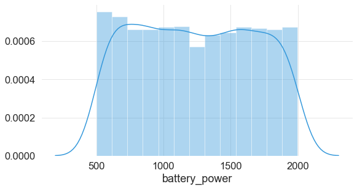

```python
print (df_train.battery_power.describe())
plt.figure(figsize=(20,10))
plt.subplot(2,2,1)
sns.distplot(df_train.battery_power);
```

### Battery power is a continuous variable

### 2. blue

Has bluetooth or not. Categorical variable

```python
print ("Unique values :\n")
df_train.blue.unique()
```

```
Unique values :
```

```
array([0, 1], dtype=int64)
```

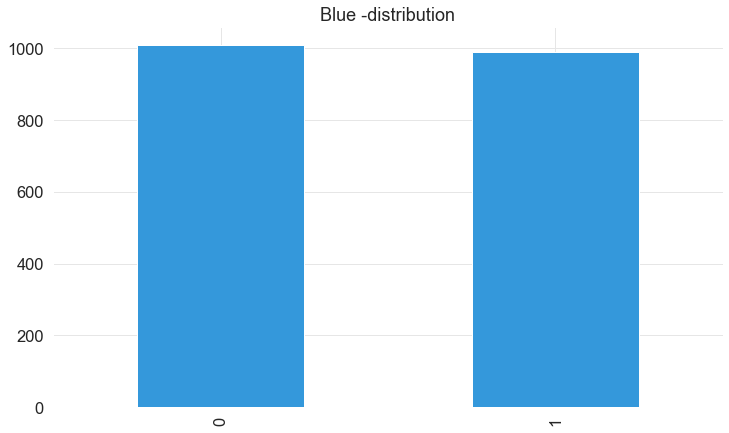

```python
df_train.blue.value_counts().plot.bar();
plt.title("Blue -distribution");
```

### blue is a categorical variable.

### 3. clock speed

```python
df_train.clock_speed.describe()
```

```
count    2000.000000
mean        1.522250
std         0.816004
min         0.500000
25%         0.700000
50%         1.500000
75%         2.200000
max         3.000000
Name: clock_speed, dtype: float64
```

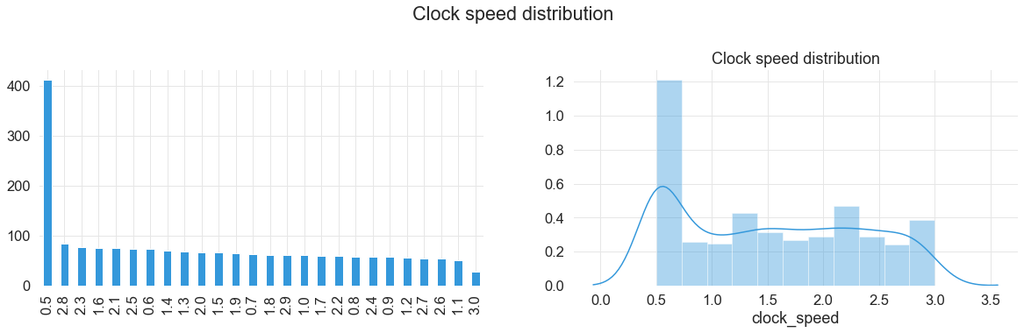

```python
plt.figure(figsize=(20,10));
plt.suptitle("Clock speed distribution");
plt.subplot(2,2,2)
sns.distplot(df_train.clock_speed).set_title("Clock speed distribution");
plt.subplot(2,2,1)
df_train.clock_speed.value_counts().plot.bar();
```

### clock speed is a continuous variable.

### 4. Dual sim

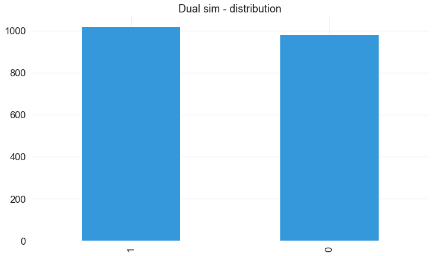

```python
df_train.dual_sim.value_counts().plot.bar().set_title("Dual sim - distribution");
```

### Dual sim is categorical variable.

### 5. Fc

Front camera megapixels

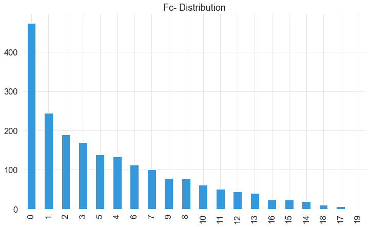

```python
df_train.fc.value_counts().plot.bar().set_title("Fc- Distribution");
```

### Front camera pixels is categorical variable.

### 6. Four G

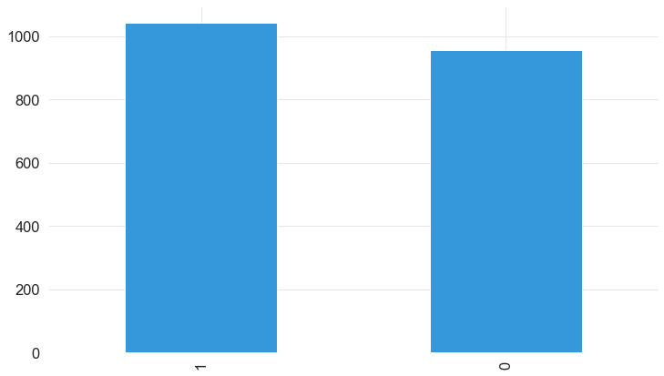

```python
df_train.four_g.value_counts().plot.bar();
```

### Four G is categorical variable.

### 7. Int memory

```python
print ("Unique values: \n", np.sort(df_train.int_memory.unique()))
```

```
Unique values:
 [ 2  3  4  5  6  7  8  9 10 11 12 13 14 15 16 17 18 19 20 21 22 23 24 25
 26 27 28 29 30 31 32 33 34 35 36 37 38 39 40 41 42 43 44 45 46 47 48 49
 50 51 52 53 54 55 56 57 58 59 60 61 62 63 64]
```

```python
print ("Value description: \n",df_train.int_memory.describe())
```

```
Value description:
 count    2000.000000
mean       32.046500
std        18.145715
min         2.000000
25%        16.000000
50%        32.000000
75%        48.000000
max        64.000000
Name: int_memory, dtype: float64
```

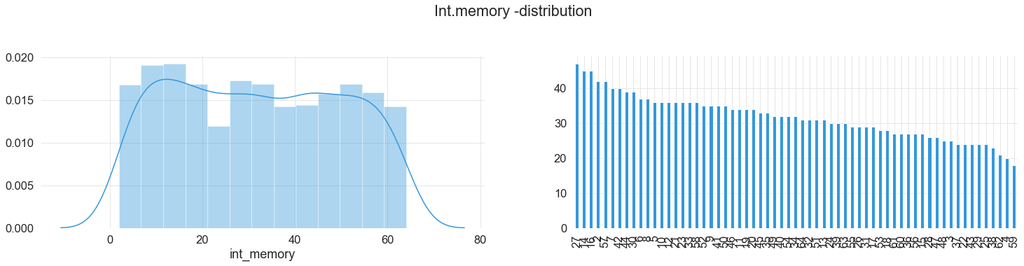

```python
plt.figure(figsize=(25,10))
plt.subplot(2,2,1)
sns.distplot(df_train.int_memory)
plt.subplot(2,2,2)
df_train.int_memory.value_counts().plot.bar();
plt.suptitle("Int.memory -distribution");
```

### Int. memory is categorical variable.

### 8. M Dep

Mobile Depth in cm

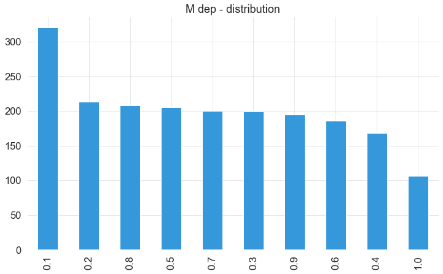

```python
df_train.m_dep.value_counts().plot.bar();
plt.title("M dep - distribution");
```

### M Dep is continuous variable.

### 9. Mobile wt

```python
df_train.mobile_wt.describe()
```

```
count    2000.000000
mean      140.249000
std        35.399655
min        80.000000
25%       109.000000
50%       141.000000
75%       170.000000
max       200.000000
Name: mobile_wt, dtype: float64
```

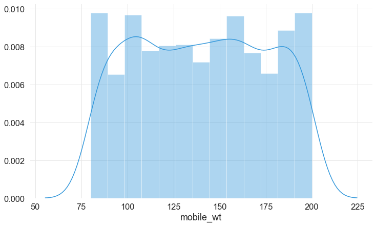

```python
sns.distplot(df_train.mobile_wt);
```

### Mobile wt. is continuous variable.

### 10. N cores

Number of cores of the processor

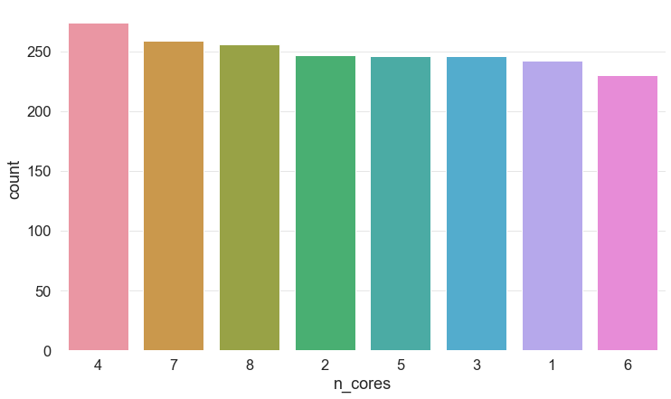

```python
sns.countplot(data=df_train, x="n_cores", order=df_train.n_cores.value_counts().index);
```

### N cores is categorical variable.

### 11.Pc

Primary Camera Megapixes

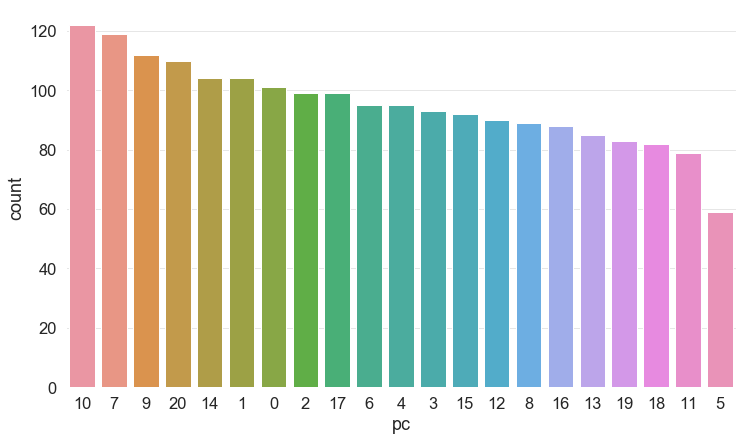

```python
sns.countplot(data=df_train,x="pc",order=df_train.pc.value_counts().index);
```

```python
print ("Unique values : \n")
df_train.pc.unique()
```

```
Unique values :
```

```
array([ 2,  6,  9, 14,  7, 10,  0, 15,  1, 18, 17, 11, 16,  4, 20, 13,  3,
       19,  8,  5, 12], dtype=int64)
```

### Primary camera mega pixels is categorical variable.

### 12. Price Range

This will be target category.

```python
print ("Unique values: \n")
df_train.price_range.unique()
```

```
Unique values:
```

```
array([1, 2, 3, 0], dtype=int64)
```

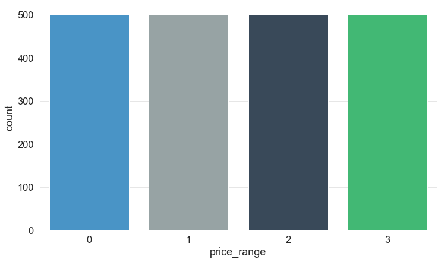

```python
sns.countplot(data=df_train,x="price_range");
```

### All price ranges got equal distributions. Price range is a categorical variable.

### 13. Px Height

Pixel Resolution Height

```python
df_train.px_height.describe()
```

```
count    2000.000000
mean      645.108000
std       443.780811
min         0.000000
25%       282.750000
50%       564.000000
75%       947.250000
max      1960.000000
Name: px_height, dtype: float64
```

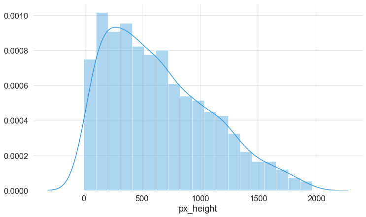

```python
sns.distplot(df_train.px_height);
```

```python
print ("Observations having zero pixel resolution :\n")
df_train[df_train["px_height"]==0]
```

```
Observations having zero pixel resolution :
```

|  | battery_power | blue | clock_speed | dual_sim | fc | four_g | int_memory | m_dep | mobile_wt | n_cores | ... | px_height | px_width | ram | sc_h | sc_w | talk_time | three_g | touch_screen | wifi | price_range |
| --- | --- | --- | --- | --- | --- | --- | --- | --- | --- | --- | --- | --- | --- | --- | --- | --- | --- | --- | --- | --- | --- |
| 1481 | 1834 | 0 | 2.1 | 0 | 7 | 1 | 40 | 0.1 | 99 | 4 | ... | 0 | 1987 | 3692 | 13 | 0 | 16 | 1 | 1 | 0 | 3 |
| 1933 | 897 | 1 | 2.0 | 0 | 3 | 1 | 2 | 0.6 | 154 | 8 | ... | 0 | 994 | 1958 | 7 | 5 | 7 | 1 | 1 | 0 | 1 |

2 rows × 21 columns

### 2 records having pixel height = 0 doesn't make sense. As the pixel height increases , number of observations gradualy reduces. Px Height is continuous variable.

### 14. Px Width

Pixel resolution width

```python
df_train.px_width.describe()
```

```
count    2000.000000
mean     1251.515500
std       432.199447
min       500.000000
25%       874.750000
50%      1247.000000
75%      1633.000000
max      1998.000000
Name: px_width, dtype: float64
```

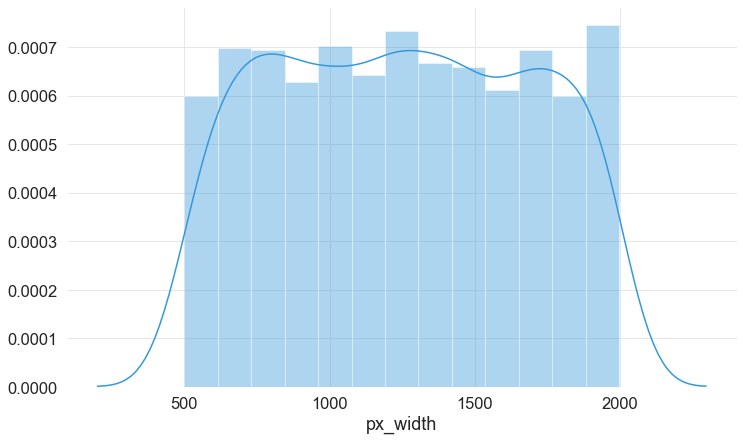

```python
sns.distplot(df_train.px_width);
```

### 15. Ram

```python
df_train.ram.describe()
```

```
count    2000.000000
mean     2124.213000
std      1084.732044
min       256.000000
25%      1207.500000
50%      2146.500000
75%      3064.500000
max      3998.000000
Name: ram, dtype: float64
```

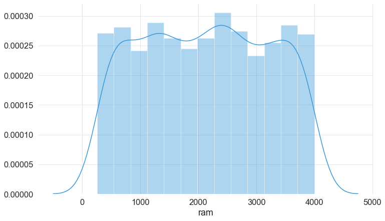

```python
sns.distplot(df_train.ram);
```

### Ram is continuous variable.

### 16.Sc H

Screen height of mobile in CM.

```python
print ("Unique values: \n")
np.sort(df_train.sc_h.unique())
```

```
Unique values:
```

```
array([ 5,  6,  7,  8,  9, 10, 11, 12, 13, 14, 15, 16, 17, 18, 19],
      dtype=int64)
```

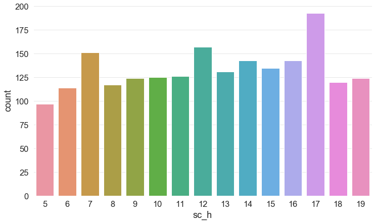

```python
sns.countplot(df_train.sc_h);
```

### Screen height is continuous variable.

### 17. Sc.W

Screen width of mobile in CM

```python
print ("Unique values : \n")
np.sort(df_train.sc_w.unique())
```

```
Unique values :
```

```
array([ 0,  1,  2,  3,  4,  5,  6,  7,  8,  9, 10, 11, 12, 13, 14, 15, 16,
       17, 18], dtype=int64)
```

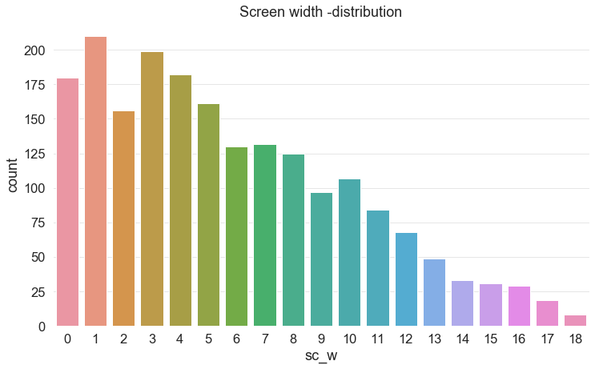

```python
sns.countplot(df_train.sc_w).set_title("Screen width -distribution");
```

### Screen width is continuous variable.

### 18. Talk time

Maximum talking time for single charge

```python
df_train.talk_time.describe()
```

```
count    2000.000000
mean       11.011000
std         5.463955
min         2.000000
25%         6.000000
50%        11.000000
75%        16.000000
max        20.000000
Name: talk_time, dtype: float64
```

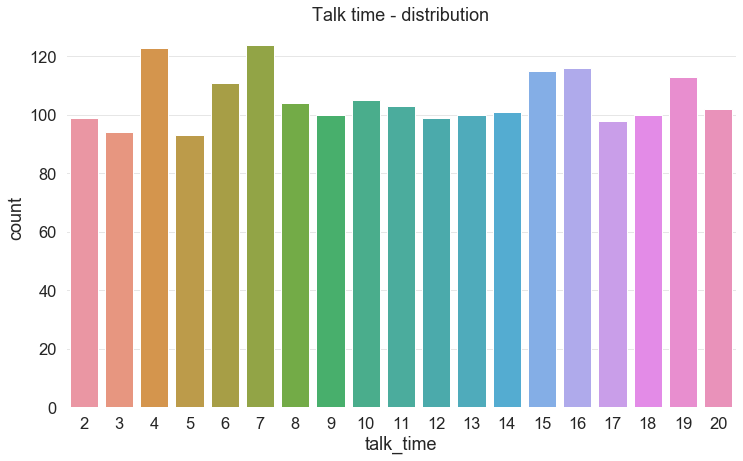

```python
sns.countplot(df_train.talk_time);
plt.title("Talk time - distribution");
```

### Talk time is continuous variable.

### 19. Three G

```python
print ("Unique values: \n")
df_train.three_g.unique()
```

```
Unique values:
```

```
array([0, 1], dtype=int64)
```

```
Value counts for Three G:  (array([0, 1], dtype=int64), array([ 477, 1523], dtype=int64))
```

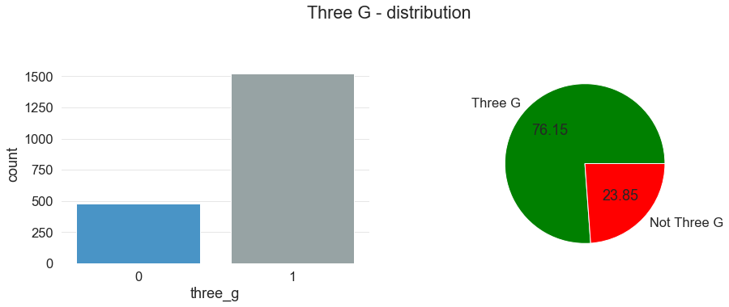

```python
plt.figure(figsize=(15,10))
plt.subplot(2,2,1)
sns.countplot(df_train.three_g);
plt.subplot(2,2,2)
print ("Value counts for Three G: ",np.unique(df_train.three_g,return_counts=True))
plt.pie(df_train.three_g.value_counts(),autopct="%.2f",colors=['green','red'],labels=["Three G","Not Three G"]);
plt.suptitle("Three G - distribution");
```

### Three G is discrete variable.

### 20. Touch screen

```python
print ("Value counts: \n")
df_train.touch_screen.value_counts()
```

```
Value counts:
```

```
1    1006
0     994
Name: touch_screen, dtype: int64
```

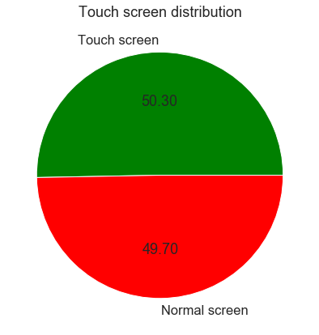

```python
plt.pie(df_train.touch_screen.value_counts(),autopct="%.2f",colors=['green','red'],labels=["Touch screen", "Normal screen"]);
plt.title("Touch screen distribution");
```

### Touch screen and normal screen are almost same distribution in the dataset. Is a discrete variable.

### 21. Wifi

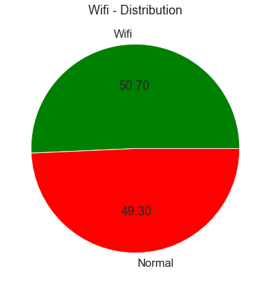

```python
plt.pie(df_train.wifi.value_counts(),autopct="%.2f",colors=['green','red'],labels=["Wifi", "Normal"]);
plt.title("Wifi - Distribution");
```

### Mobiles with wifi and without wifi are almost same in count. Discrete variable.

## Feature relations

### Battery power vs. Price range

```python
df_dummy=df_train.copy()
```

```python
def find_range(val):
    if val<=1000:
        return "low"
    elif val >1000 and val<=1500:
        return "Mid"
    elif val > 1500 :
        return "High"
```

```python
df_dummy['battery_range']=df_dummy.battery_power.apply(find_range)
```

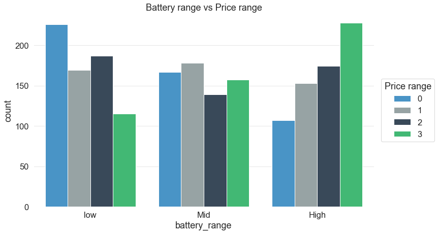

```python
sns.countplot(data=df_dummy,x="battery_range",hue="price_range");
plt.legend(loc='center',bbox_to_anchor=(1.1, 0.5),title="Price range");
plt.title("Battery range vs Price range");
```

### Battery power < 1000 considering as low. Having more number of phones in Price range 0. Battery power 1000-1500 considering as Mid. Having all the price ranges in almost same count. Battery power >1500 considering as High.having more number of phones in Price range 3.

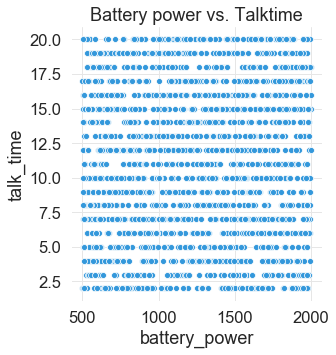

```python
sns.relplot(data=df_train,x="battery_power",y="talk_time");
plt.title("Battery power vs. Talktime");
```

### There is no direct relation between battery power and talk time in the dataset. There are mobiles with less battery power with more talk time.

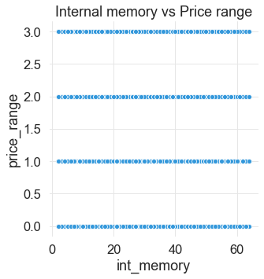

```python
sns.relplot(data=df_train,x="int_memory",y="price_range");
plt.title("Internal memory vs Price range");
```

### Mobiles having all ranges of internal memory, lies in all price ranges. There are mobiles with less memory having high price range and vice versa.

## Training the model and Prediction

```python
df_input=df_train.copy()
```

```python
def update_df(df_inp):
    categorical_cols=["fc","int_memory","n_cores","pc"]
    for col in categorical_cols:
        print ("Creating categorical columns for ", col)
        df_inp=pd.concat([df_inp,pd.get_dummies(df_inp[col],prefix=col)],axis=1)
        df_inp.drop([col],axis=1,inplace=True)
        print ("Deleted original col ", col)
    return df_inp
```

```python
df_input=update_df(df_input)
```

```
Creating categorical columns for  fc
Deleted original col  fc
Creating categorical columns for  int_memory
Deleted original col  int_memory
Creating categorical columns for  n_cores
Deleted original col  n_cores
Creating categorical columns for  pc
Deleted original col  pc
```

```python
x=df_input.drop('price_range',axis=1)
y=df_input.price_range
```

```python
def standardize_df(df_inp):
    cont_variables=['battery_power','clock_speed','m_dep','mobile_wt','px_height','px_width','ram','sc_h','sc_w','talk_time']
    for var in cont_variables:
        df_inp[var]=standardize(df_inp[var])
        print ("Standardized feature : ", var)
    return df_inp
```

```python
x=standardize_df(x)
```

```
Standardized feature :  battery_power
Standardized feature :  clock_speed
Standardized feature :  m_dep
Standardized feature :  mobile_wt
Standardized feature :  px_height
Standardized feature :  px_width
Standardized feature :  ram
Standardized feature :  sc_h
Standardized feature :  sc_w
Standardized feature :  talk_time
```

```python
def get_score_data(x,y):
    score_data={
        "LogisticRegression":cross_val_score(LogisticRegression(),x,y),
        "SVM": cross_val_score(SVC(),x,y),
        "RandomForest": cross_val_score(RandomForestClassifier(),x,y),
        "DecisionTree": cross_val_score(DecisionTreeClassifier(),x,y),
        "XGradientBoosting": cross_val_score(XGBClassifier(),x,y),
        "KNN": cross_val_score(KNeighborsClassifier(),x,y)
    }
    df_score_data = pd.DataFrame(data=score_data)
    print ("Cross validation score:\n ", df_score_data)
    print ("Mean score:\n", df_score_data.mean().sort_values(ascending=False))
```

```python
get_score_data(x,y)
```

```
Cross validation score:
     LogisticRegression     SVM  RandomForest  DecisionTree  XGradientBoosting  \
0              0.9175  0.9075        0.8400        0.8200             0.9250
1              0.9200  0.9000        0.8425        0.8450             0.9225
2              0.9375  0.9350        0.8450        0.8150             0.9125
3              0.9175  0.9000        0.8425        0.8175             0.9175
4              0.9325  0.9000        0.8475        0.8400             0.8800

      KNN
0  0.6175
1  0.6300
2  0.5875
3  0.6425
4  0.5825
Mean score:
 LogisticRegression    0.9250
XGradientBoosting     0.9115
SVM                   0.9085
RandomForest          0.8435
DecisionTree          0.8275
KNN                   0.6120
dtype: float64
```

### Logistic Regression model got highest score.

```python
print ("Train Test splitting..")
x_train,x_test,y_train,y_test=train_test_split(x,y,test_size=0.3,random_state=1)
```

```
Train Test splitting..
```

```python
print ("Fitting Logistic Regression..")
lr=LogisticRegression()
lr.fit(x_train,y_train)
```

```
Fitting Logistic Regression..
```

```
LogisticRegression(C=1.0, class_weight=None, dual=False, fit_intercept=True,
                   intercept_scaling=1, l1_ratio=None, max_iter=100,
                   multi_class='auto', n_jobs=None, penalty='l2',
                   random_state=None, solver='lbfgs', tol=0.0001, verbose=0,
                   warm_start=False)
```

```python
print ("Predicting target variable..")
y_pred = lr.predict(x_test)
```

```
Predicting target variable..
```

```python
print ("Confusion matrix")
confusion_matrix(y_test,y_pred,)
```

```
Confusion matrix
```

```
array([[130,   5,   0,   0],
       [  7, 134,   8,   0],
       [  0,  14, 143,  11],
       [  0,   0,   9, 139]], dtype=int64)
```

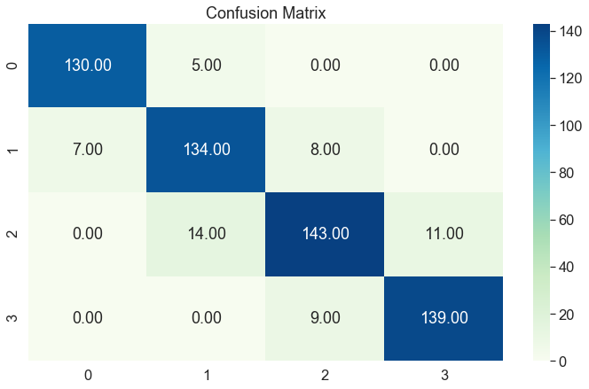

```python
plt.figure(figsize=(12,7))
sns.heatmap(confusion_matrix(y_test,y_pred),annot=True,cmap='GnBu',fmt="0.2f");
plt.title("Confusion Matrix");
```

### 130,134,143,139 values are able to predict correctly as 0,1,2,3. 7 values predicted as 0 which is actually 1. 5 values predicted as 1 which is actually 0. 8 values predicted as 2 which is actually 1. 9 values predicted as 2 which is actually 3. 11 values predicted as 3 which is actually 2.

```python
print ("Classification report:")
print (classification_report(y_true= y_test,y_pred=y_pred))
```

```
Classification report:
              precision    recall  f1-score   support

           0       0.95      0.96      0.96       135
           1       0.88      0.90      0.89       149
           2       0.89      0.85      0.87       168
           3       0.93      0.94      0.93       148

    accuracy                           0.91       600
   macro avg       0.91      0.91      0.91       600
weighted avg       0.91      0.91      0.91       600
```

Precision tp/(tp+fp) : measures the ability of a classifier to identify only the correct instances for each class.  
Recall tp/(tp+fn) : is the ability of the classifier to find all correct instances per class.  
F1 Score = 2 *(precision* recall)/ (precision + recall)  
F1 score is considered a better indicator of the classifier's performance than the regular accuracy measure.  
Support is the number of actual occurances of the class in the test data set.

```python
df_dummy=pd.DataFrame()
df_dummy['test']=pd.Series(y_test.values)
df_dummy['pred']=pd.Series(y_pred)
```

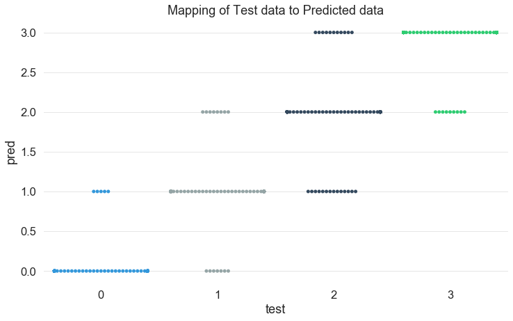

```python
sns.swarmplot(data=df_dummy,x="test",y='pred');
plt.title("Mapping of Test data to Predicted data");
```

## Test file prediction

```python
df_test=pd.read_csv('test.csv')
print ("Test file loaded.")
print ("Shape of test file: ", df_test.shape)
print ("Sample test file")
df_test.head()
```

```
Test file loaded.
Shape of test file:  (1000, 21)
Sample test file
```

|  | id | battery_power | blue | clock_speed | dual_sim | fc | four_g | int_memory | m_dep | mobile_wt | ... | pc | px_height | px_width | ram | sc_h | sc_w | talk_time | three_g | touch_screen | wifi |
| --- | --- | --- | --- | --- | --- | --- | --- | --- | --- | --- | --- | --- | --- | --- | --- | --- | --- | --- | --- | --- | --- |
| 0 | 1 | 1043 | 1 | 1.8 | 1 | 14 | 0 | 5 | 0.1 | 193 | ... | 16 | 226 | 1412 | 3476 | 12 | 7 | 2 | 0 | 1 | 0 |
| 1 | 2 | 841 | 1 | 0.5 | 1 | 4 | 1 | 61 | 0.8 | 191 | ... | 12 | 746 | 857 | 3895 | 6 | 0 | 7 | 1 | 0 | 0 |
| 2 | 3 | 1807 | 1 | 2.8 | 0 | 1 | 0 | 27 | 0.9 | 186 | ... | 4 | 1270 | 1366 | 2396 | 17 | 10 | 10 | 0 | 1 | 1 |
| 3 | 4 | 1546 | 0 | 0.5 | 1 | 18 | 1 | 25 | 0.5 | 96 | ... | 20 | 295 | 1752 | 3893 | 10 | 0 | 7 | 1 | 1 | 0 |
| 4 | 5 | 1434 | 0 | 1.4 | 0 | 11 | 1 | 49 | 0.5 | 108 | ... | 18 | 749 | 810 | 1773 | 15 | 8 | 7 | 1 | 0 | 1 |

5 rows × 21 columns

```python
del([df_dummy,df_input])
```

```python
df_input=df_test.copy()
```

```python
print ("Test file features: ", df_input.columns)
```

```
Test file features:  Index(['id', 'battery_power', 'blue', 'clock_speed', 'dual_sim', 'fc',
       'four_g', 'int_memory', 'm_dep', 'mobile_wt', 'n_cores', 'pc',
       'px_height', 'px_width', 'ram', 'sc_h', 'sc_w', 'talk_time', 'three_g',
       'touch_screen', 'wifi'],
      dtype='object')
```

```python
df_input=update_df(df_input)
```

```
Creating categorical columns for  fc
Deleted original col  fc
Creating categorical columns for  int_memory
Deleted original col  int_memory
Creating categorical columns for  n_cores
Deleted original col  n_cores
Creating categorical columns for  pc
Deleted original col  pc
```

```python
x=df_input.drop('id',axis=1)
```

```python
x=standardize_df(x)
```

```
Standardized feature :  battery_power
Standardized feature :  clock_speed
Standardized feature :  m_dep
Standardized feature :  mobile_wt
Standardized feature :  px_height
Standardized feature :  px_width
Standardized feature :  ram
Standardized feature :  sc_h
Standardized feature :  sc_w
Standardized feature :  talk_time
```

```python
y_pred=lr.predict(x)
```

```python
print ("Appending predicted price range to Test file..")
df_test["PriceRangePredicted"]=pd.Series(y_pred)
```

```
Appending predicted price range to Test file..
```

```python
df_test
```

|  | id | battery_power | blue | clock_speed | dual_sim | fc | four_g | int_memory | m_dep | mobile_wt | ... | px_height | px_width | ram | sc_h | sc_w | talk_time | three_g | touch_screen | wifi | PriceRangePredicted |
| --- | --- | --- | --- | --- | --- | --- | --- | --- | --- | --- | --- | --- | --- | --- | --- | --- | --- | --- | --- | --- | --- |
| 0 | 1 | 1043 | 1 | 1.8 | 1 | 14 | 0 | 5 | 0.1 | 193 | ... | 226 | 1412 | 3476 | 12 | 7 | 2 | 0 | 1 | 0 | 3 |
| 1 | 2 | 841 | 1 | 0.5 | 1 | 4 | 1 | 61 | 0.8 | 191 | ... | 746 | 857 | 3895 | 6 | 0 | 7 | 1 | 0 | 0 | 3 |
| 2 | 3 | 1807 | 1 | 2.8 | 0 | 1 | 0 | 27 | 0.9 | 186 | ... | 1270 | 1366 | 2396 | 17 | 10 | 10 | 0 | 1 | 1 | 2 |
| 3 | 4 | 1546 | 0 | 0.5 | 1 | 18 | 1 | 25 | 0.5 | 96 | ... | 295 | 1752 | 3893 | 10 | 0 | 7 | 1 | 1 | 0 | 3 |
| 4 | 5 | 1434 | 0 | 1.4 | 0 | 11 | 1 | 49 | 0.5 | 108 | ... | 749 | 810 | 1773 | 15 | 8 | 7 | 1 | 0 | 1 | 1 |
| ... | ... | ... | ... | ... | ... | ... | ... | ... | ... | ... | ... | ... | ... | ... | ... | ... | ... | ... | ... | ... | ... |
| 995 | 996 | 1700 | 1 | 1.9 | 0 | 0 | 1 | 54 | 0.5 | 170 | ... | 644 | 913 | 2121 | 14 | 8 | 15 | 1 | 1 | 0 | 2 |
| 996 | 997 | 609 | 0 | 1.8 | 1 | 0 | 0 | 13 | 0.9 | 186 | ... | 1152 | 1632 | 1933 | 8 | 1 | 19 | 0 | 1 | 1 | 1 |
| 997 | 998 | 1185 | 0 | 1.4 | 0 | 1 | 1 | 8 | 0.5 | 80 | ... | 477 | 825 | 1223 | 5 | 0 | 14 | 1 | 0 | 0 | 1 |
| 998 | 999 | 1533 | 1 | 0.5 | 1 | 0 | 0 | 50 | 0.4 | 171 | ... | 38 | 832 | 2509 | 15 | 11 | 6 | 0 | 1 | 0 | 2 |
| 999 | 1000 | 1270 | 1 | 0.5 | 0 | 4 | 1 | 35 | 0.1 | 140 | ... | 457 | 608 | 2828 | 9 | 2 | 3 | 1 | 0 | 1 | 2 |

1000 rows × 22 columns

```python
print ('Exporting to predicted.csv')
df_test.to_csv('predicted.csv',index=False)
```

```
Exporting to predicted.csv
```